# Time Series Data Preparation

**Install Require Packages And Functions:**

```r
if(!"devtools" %in% installed.packages()) install.packages("devtools")

InstallPackagesGIT <-
'https://raw.githubusercontent.com/kamilbanas85/R_usefull_functions/master/Install_And_Load_Packages.R'
ClearDataGIT <-
'https://raw.githubusercontent.com/kamilbanas85/R_usefull_functions/master/Clear_Data_Functions.R'
DataTranformationGIT <-
'https://raw.githubusercontent.com/kamilbanas85/R_usefull_functions/master/Data_Transformation.R'

devtools::source_url(InstallPackagesGIT)
devtools::source_url(ClearDataGIT)
devtools::source_url(DataTranformationGIT)

listOfPackages <- c('dplyr', 'ggplot2', 'tidyr','xts')
InstallAndLoadRequirePackages(listOfPackages)

rm(InstallPackagesGIT, ClearDataGIT, DataTranformationGIT, listOfPackages)
```

**Check data in general:**

```r
    DataFrameEx %>% glimpse()
```

```
   ## Rows: 4,931
   ## Columns: 2
   ## $ Date       <date> 2007-01-01, 2007-01-02, 2007-01-03, 2007-01-04, 2007-01...
   ## $ ColumnName <dbl> 1.995074, 1.683354, 1.542804, 2.585756, 1.880426, 4.0694...
```

**Plot data:**

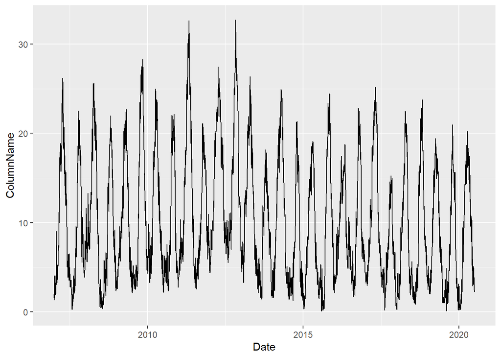

```r
    DataFrameEx %>% ggplot() + geom_line(aes(Date, ColumnName))
```

**Repair ‘Date’ column:**

- remove NA from the top and bottom data
- complite missing dates
- remove dupicated dates

**Check top and bottom values:**

```r
  DataFrameEx %>% head()
  DataFrameEx %>% tail()
```

If missing some top and bottom Dates -> remove it (function from ‘Clear_Data_Functions.R’ on GitGub):

```r
  DataFrameEx <- DataFrameEx %>%
      RemoveTopAndBottomRowsWithNA(columnName = Date)
```

**Check dupicates on ‘Date’ column:**

Extract duplicated elements:

```r
DataFrameEx %>% .[duplicated(.), 'Date']
```

Remove duplicates based on ‘Date’ column:

```r
  DataFrameEx <- DataFrameEx %>%
                      .[!duplicated(.$Date), ]
```

or using a function from ‘dplyr’:

```r
  DataFrameEx %>% distinct(Date, .keep_all = TRUE)
```

**Complate ‘Date’ column - replace ‘NA’, ‘None’ etc.:**

Check missing data in ‘Date’ column to knwolage:

```r
  is.na(DataFrameEx$Date) %>% table()
```

Fill ‘Date’ column with sequence of dates:

```r
  DataFrameEx <- DataFrameEx %>%
                    tidyr::complete(Date = seq.Date(min(Date, na.rm = TRUE),
                                      max(Date, na.rm = TRUE), by = 'day'))
```

**Repair rest of a data**

- remove NA from the top and bottom data
- fill missing datas

**Functions to replace NA:**

**fill()** - replace NA with previous or next value. Example:

```r
  DataFrameEx <- DataFrameEx %>%
                      fill(ColumnName)
```

**replace_na()** - replace NA with specified value. Example, replace with ‘0’

```r
  DataFrameEx <- DataFrameEx %>%
                      mutate(ColumnName = replace_na(ColumnName, 0))
```

**Direct replacemnt**

```r
  DataFrameEx$ColumnName[is.na(DataFrameEx$ColumnName)] <- 0
```

**xts::na.locf()** - fill NA with a last or next known value. Example, ( DataFrameToXTS from ‘Data_Transformation’ functions):

```r
DataFrameEx %>%
      DataFrameToXTS() %>%
      na.locf()
```

**xts::na.approx()** - fill NA with linear interpolation. Example, ( DataFrameToXTS from ‘Data_Transformation’ functions):

```r
DataFrameEx %>%
      DataFrameToXTS() %>%
      na.approx()
```

**Functions to remove NA:**

**na.omit()** - remove row with NA based on all data or specific column. Example:

```r
  DataFrameEx <- DataFrameEx %>%
                      na.omit()
```

**drop_na()** - remove rows with NA in sepecific column. Example:

```r
  DataFrameEx <- DataFrameEx %>%
                      drop_na(ColumnName)
```